# Differential expression analysis of all stimuli compared to unstimulated in 1 region only

Gijsje

2/16/2021

```r
load("~/Documents/MiGASti/Databases/gene_matrix.RData")
metadata <- read.table("~/Documents/MiGASti/Databases/metadata.txt")
#set rownames to Sample
row.names(metadata) <- metadata$Sample
setwd("~/Documents/MiGASti/Databases")
#exclude samples that did not pass QC filtering
exclude <- read.table("samples2remove.txt")
exclude <- exclude$x
genes_counts_filt = genes_counts[, !colnames(genes_counts) %in% exclude]
#Excludes the samples from filters.
#dim(genes_counts_filt)
metadata_filt = metadata[ !(rownames(metadata) %in% exclude), ]
length(metadata_filt)
gencode_30 = read.table("~/Documents/MiGASti/Databases/ens.geneid.gencode.v30")
colnames(gencode_30) = c("ensembl","symbol")
#remove low count genes
cpm <- cpm(genes_counts_filt)
# CPM >= 1 in at least 50% of the samples
keep.exp <- rowSums(cpm > 1) >= (0.5 * ncol(genes_counts_filt) )
genes_counts_filt1 <- genes_counts_filt[ keep.exp, ] #18997 genes
#order metadata and genes counts
genes_counts_ordered <- genes_counts_filt1[,rownames(metadata_filt)]
#head(genes_counts_ordered)
all(rownames(metadata_filt) == colnames (genes_counts_ordered)) #TRUE
```

```r
# Counts, TPM, voom and metadata filtered
# 496 samples!
# Filter for genes not expressed: 50 % of the samples!
# dim(genes_counts_ordered) #18997   496
# dim(metadata_filt) #496  38
```

# Preparing the samples for DEG

```r
#remove uncultured samples
metadata_cultured <- metadata_filt[metadata_filt$Stimulation != "ununstim",]
#check numbers
#dim(metadata_cultured)
#check numbers per stimulation
#table(metadata_filt$Stimulation)
#select only GFM samples in metadata
metadata_GFM = metadata_cultured[metadata_cultured$Region=="GFM",]
#select only GFM samples in genes counts
genes_counts_GFM <- genes_counts_ordered[,metadata_GFM$Sample]
#order metadata and genes_counts
genes_counts_GFM_ordered <- genes_counts_GFM[,rownames(metadata_GFM)]
#check ordering
all(rownames(metadata_GFM) == colnames (genes_counts_GFM_ordered)) #TRUE
```

[1] TRUE

```r
#round counts; deseq2 can only handle integers
genes_counts_GFM_ordered <- round(genes_counts_GFM_ordered, digits=0)

#make sure covariate variables are the right format
#cannot create dds object with numeric values
metadata_GFM$Donor_id <- as.factor(metadata_GFM$Donor_id)
metadata_GFM$age <- as.integer(metadata_GFM$age)
metadata_GFM$Stimulation <- as.factor(metadata_GFM$Stimulation)
metadata_GFM$picard_pct_ribosomal_bases = scale(metadata_GFM$picard_pct_ribosomal_bases)
metadata_GFM$picard_pct_mrna_bases = scale(metadata_GFM$picard_pct_mrna_bases)
metadata_GFM$picard_pct_pf_reads_aligned = scale(metadata_GFM$picard_pct_pf_reads_aligned)
metadata_GFM$picard_pct_percent_duplication = scale(metadata_GFM$picard_pct_percent_duplication)

#adjust for: ~ age + (1|donor_id) + picard_pct_ribosomal_bases + picard_pct_mrna_bases + (1|sex)  + picard_pct_percent_duplication + picard_pct_pf_reads_aligned
```

# DESeq2 of GFM samples

```r
#createDeSEQ2 object for LPS
dds <- DESeqDataSetFromMatrix(countData = genes_counts_GFM_ordered,
                              colData = metadata_GFM,
                              design = ~ age + picard_pct_ribosomal_bases + picard_pct_mrna_bases + picard_pct_percent_duplication + picard_pct_pf_reads_aligned + Stimulation)
#variable of interest at end of the formula

#Make sure that control group is set as the reference group
dds$Stimulation <- relevel(dds$Stimulation, ref="unstim")
table(dds$Stimulation)
```

unstim ATP DEX IFNy IL4 LPS R848 TNFa 38 4 10 23 8 35 17 23

```r
#head(dds)

#Run differential expression
dds <- DESeq(dds, betaPrior = FALSE)
resultsNames(dds)
```

[1] “Intercept” “age”  
[3] “picard_pct_ribosomal_bases” “picard_pct_mrna_bases”  
[5] “picard_pct_percent_duplication” “picard_pct_pf_reads_aligned”  
[7] “Stimulation_ATP_vs_unstim” “Stimulation_DEX_vs_unstim”  
[9] “Stimulation_IFNy_vs_unstim” “Stimulation_IL4_vs_unstim”  
[11] “Stimulation_LPS_vs_unstim” “Stimulation_R848_vs_unstim”  
[13] “Stimulation_TNFa_vs_unstim”

# DESeq2: LPS vs unstim

### Number of differentially expressed genes

```r
# generate results table for LPS vs unstim
res_LPS <- results(dds, name="Stimulation_LPS_vs_unstim")
sum(res_LPS$padj < 0.05, na.rm=TRUE)
```

[1] 334

```r
resOrdered_LPS <- res_LPS[order(res_LPS$pvalue),]
resOrdered_LPS <- as.data.frame(resOrdered_LPS)
```

### Vulcano plot LPS vs unstim

```r
head(res_LPS)
```

log2 fold change (MLE): Stimulation LPS vs unstim Wald test p-value: Stimulation LPS vs unstim DataFrame with 6 rows and 6 columns baseMean log2FoldChange lfcSE stat pvalue ENSG00000000003.14 19.7415 0.314058 0.340803 0.921524 0.356777 ENSG00000000419.12 220.9662 0.128269 0.171491 0.747963 0.454483 ENSG00000000457.14 90.9514 0.186170 0.176161 1.056817 0.290595 ENSG00000000460.17 28.2773 -0.367811 0.198302 -1.854806 0.063624 ENSG00000000938.13 516.4009 0.132277 0.142646 0.927309 0.353766 ENSG00000000971.15 50.2049 0.433994 0.320039 1.356065 0.175078 padj ENSG00000000003.14 0.797620 ENSG00000000419.12 0.846111 ENSG00000000457.14 0.750113 ENSG00000000460.17 0.468112 ENSG00000000938.13 0.796362 ENSG00000000971.15 0.657603

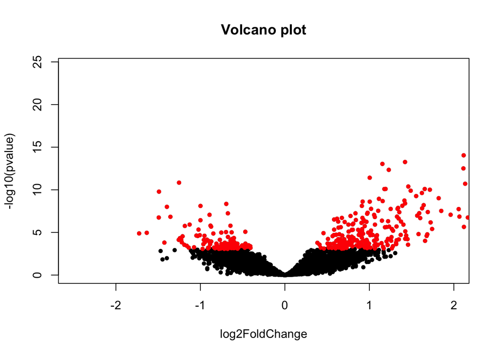

```r
with(res_LPS, plot(log2FoldChange, -log10(pvalue), pch=20, main="Volcano plot", xlim=c(-2.5,2)))
with(subset(res_LPS, padj<.05 ), points(log2FoldChange, -log10(pvalue), pch=20, col="red"))
```

### MA plot LPS vs unstim

#The function plotMA shows the log2 fold changes attributable to a given variable over the mean of normalized counts for all the samples in the DESeqDataSet. Points will be colored if the adjusted p value is less than 0.1. Points which fall out of the window are plotted as open triangles pointing either up or down.

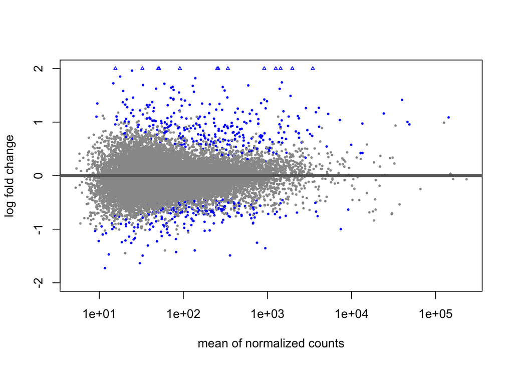

```r
plotMA(res_LPS, ylim=c(-2,2))
```

### TOP differentially expressed genes LPS vs unstim

```r
setDT(resOrdered_LPS, keep.rownames = "ensembl")
resOrdered_LPS <- left_join(resOrdered_LPS, gencode_30, by = "ensembl")
resOrdered_LPS_top = resOrdered_LPS[order(resOrdered_LPS$padj) ,]
resOrdered_LPS_top = head(resOrdered_LPS)
data.table(resOrdered_LPS_top)
```

| ensembl | baseMean | log2FoldChange | lfcSE | stat | pvalue | padj | symbol |
| --- | --- | --- | --- | --- | --- | --- | --- |
| ENSG00000136244.12 | 1433.70635 | 3.049618 | 0.2942755 | 10.363139 | 3.647887e-25 | 6.929891e-21 | IL6 |
| ENSG00000113302.4 | 91.01650 | 3.824155 | 0.3855701 | 9.918184 | 3.470127e-23 | 3.296100e-19 | IL12B |
| ENSG00000232810.4 | 3464.43167 | 2.205435 | 0.2446344 | 9.015228 | 1.964606e-19 | 1.244054e-15 | TNF |
| ENSG00000108342.12 | 916.54119 | 2.559415 | 0.3135930 | 8.161581 | 3.306676e-16 | 1.570423e-12 | CSF3 |
| ENSG00000110944.9 | 338.48055 | 2.116028 | 0.2729532 | 7.752349 | 9.020817e-15 | 3.427369e-11 | IL23A |
| ENSG00000078081.8 | 76.19055 | 1.422273 | 0.1891344 | 7.519908 | 5.481469e-14 | 1.735525e-10 | LAMP3 |

# DESeq2: IFNy vs unstim

### Number of differentially expressed genes

```r
# generate results table for IFNy vs unstim
res_IFNy <- results(dds, name="Stimulation_IFNy_vs_unstim")
sum(res_IFNy$padj < 0.05, na.rm=TRUE)
```

[1] 153

```r
resOrdered_IFNy <- res_IFNy[order(res_IFNy$pvalue),]
resOrdered_IFNy <- as.data.frame(resOrdered_IFNy)
```

### Vulcano plot IFNy vs unstim

```r
head(res_IFNy)
```

log2 fold change (MLE): Stimulation IFNy vs unstim Wald test p-value: Stimulation IFNy vs unstim DataFrame with 6 rows and 6 columns baseMean log2FoldChange lfcSE stat pvalue ENSG00000000003.14 19.7415 -0.1273936 0.380608 -0.334710 0.7378435 ENSG00000000419.12 220.9662 0.0302490 0.190613 0.158693 0.8739104 ENSG00000000457.14 90.9514 0.1368209 0.195949 0.698246 0.4850235 ENSG00000000460.17 28.2773 -0.2809683 0.218116 -1.288160 0.1976902 ENSG00000000938.13 516.4009 0.0945195 0.158762 0.595354 0.5516070 ENSG00000000971.15 50.2049 -0.6494728 0.361260 -1.797800 0.0722087 padj ENSG00000000003.14 0.889093 ENSG00000000419.12 0.950610 ENSG00000000457.14 0.752855 ENSG00000000460.17 0.536774 ENSG00000000938.13 0.789853 ENSG00000000971.15 0.383068

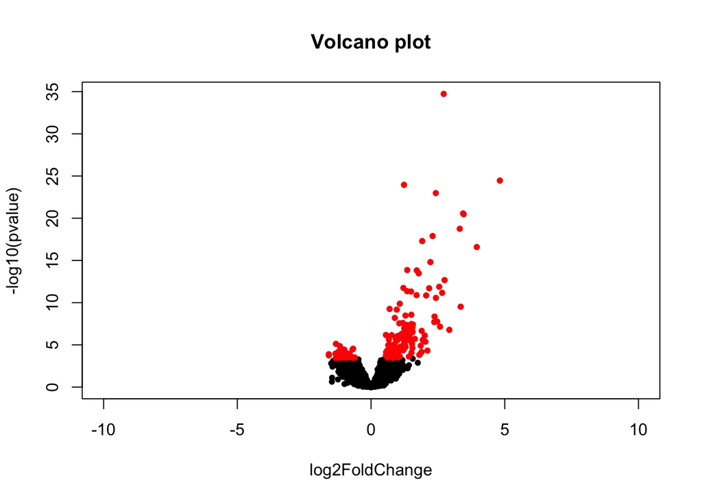

```r
with(res_IFNy, plot(log2FoldChange, -log10(pvalue), pch=20, main="Volcano plot", xlim=c(-10,10)))
with(subset(res_IFNy, padj<.05 ), points(log2FoldChange, -log10(pvalue), pch=20, col="red"))
```

### MA plot IFNy vs unstim

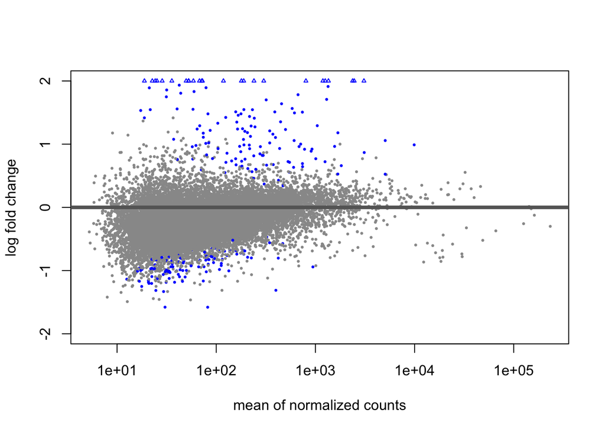

```r
plotMA(res_IFNy, ylim=c(-2,2))
```

### TOP differentially expressed genes IFNy vs unstim

```r
setDT(resOrdered_IFNy, keep.rownames = "ensembl")
resOrdered_IFNy <- left_join(resOrdered_IFNy, gencode_30, by = "ensembl")
resOrdered_IFNy_top = resOrdered_IFNy[order(resOrdered_IFNy$padj) ,]
resOrdered_IFNy_top = head(resOrdered_IFNy)
data.table(resOrdered_IFNy_top)
```

| ensembl | baseMean | log2FoldChange | lfcSE | stat | pvalue | padj | symbol |
| --- | --- | --- | --- | --- | --- | --- | --- |
| ENSG00000140105.18 | 2371.56064 | 2.716664 | 0.2186081 | 12.427097 | 1.862772e-35 | 3.469971e-31 | WARS |
| ENSG00000003989.17 | 52.82216 | 16.832022 | 1.4659017 | 11.482367 | 1.617894e-30 | 1.506906e-26 | SLC7A2 |
| ENSG00000169245.6 | 2462.77208 | 4.817014 | 0.4645711 | 10.368733 | 3.440566e-25 | 2.136362e-21 | CXCL10 |
| ENSG00000158985.13 | 499.52491 | 1.232019 | 0.1201206 | 10.256524 | 1.106167e-24 | 5.151421e-21 | CDC42SE2 |
| ENSG00000168394.11 | 802.28904 | 2.421690 | 0.2412956 | 10.036198 | 1.056693e-23 | 3.936816e-20 | TAP1 |
| ENSG00000117228.10 | 1353.56798 | 3.441985 | 0.3633273 | 9.473512 | 2.705894e-21 | 8.400899e-18 | GBP1 |

# DESeq2: TNFa vs unstim

```r
# generate results table for TNFa vs unstim
res_TNFa <- results(dds, name="Stimulation_TNFa_vs_unstim")
sum(res_TNFa$padj < 0.05, na.rm=TRUE)
```

[1] 0

```r
resOrdered_TNFa <- res_TNFa[order(res_TNFa$pvalue),]
resOrdered_TNFa <- as.data.frame(resOrdered_TNFa)
```

### Vulcano plot TNFa vs unstim

```r
head(res_TNFa)
```

log2 fold change (MLE): Stimulation TNFa vs unstim Wald test p-value: Stimulation TNFa vs unstim DataFrame with 6 rows and 6 columns baseMean log2FoldChange lfcSE stat pvalue ENSG00000000003.14 19.7415 -0.3148908 0.383501 -0.821095 0.411592 ENSG00000000419.12 220.9662 0.2649016 0.190956 1.387238 0.165369 ENSG00000000457.14 90.9514 0.2187570 0.196388 1.113904 0.265321 ENSG00000000460.17 28.2773 -0.5093535 0.222245 -2.291855 0.021914 ENSG00000000938.13 516.4009 0.0779182 0.159216 0.489387 0.624568 ENSG00000000971.15 50.2049 -0.2274183 0.358282 -0.634748 0.525593 padj ENSG00000000003.14 0.838295 ENSG00000000419.12 0.725008 ENSG00000000457.14 0.781826 ENSG00000000460.17 0.675892 ENSG00000000938.13 0.911167 ENSG00000000971.15 0.874519

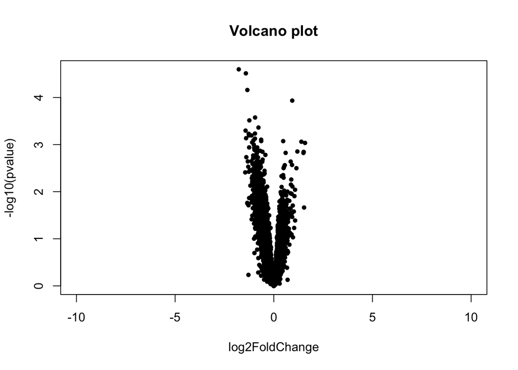

```r
with(res_TNFa, plot(log2FoldChange, -log10(pvalue), pch=20, main="Volcano plot", xlim=c(-10,10)))
with(subset(res_TNFa, padj<.05 ), points(log2FoldChange, -log10(pvalue), pch=20, col="red"))
```

### MA plot TNFa vs unstim

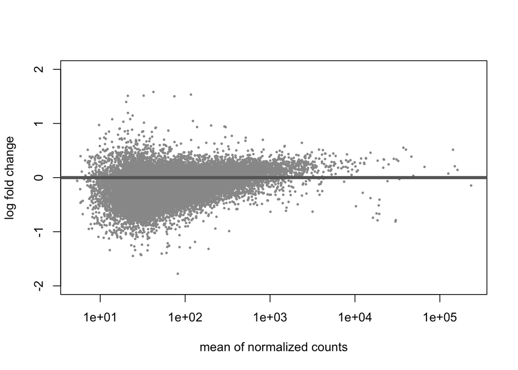

```r
plotMA(res_TNFa, ylim=c(-2,2))
```

### Top differentially expressed genes TNFa vs unstim

```r
setDT(resOrdered_TNFa, keep.rownames = "ensembl")
resOrdered_TNFa <- left_join(resOrdered_TNFa, gencode_30, by = "ensembl")
resOrdered_TNFa_top = resOrdered_TNFa[order(resOrdered_TNFa$padj) ,]
resOrdered_TNFa_top = head(resOrdered_TNFa)
data.table(resOrdered_TNFa_top)
```

| ensembl | baseMean | log2FoldChange | lfcSE | stat | pvalue | padj | symbol |
| --- | --- | --- | --- | --- | --- | --- | --- |
| ENSG00000180481.11 | 81.96211 | -1.7759933 | 0.4216086 | -4.212422 | 2.526468e-05 | 0.2919193 | GLIPR1L2 |
| ENSG00000159784.17 | 29.81790 | -1.4157584 | 0.3396762 | -4.167964 | 3.073320e-05 | 0.2919193 | FAM131B |
| ENSG00000226232.8 | 12.94946 | -1.3397894 | 0.3367587 | -3.978484 | 6.935596e-05 | 0.4391851 | NPIPB14P |
| ENSG00000121769.7 | 138.16760 | 0.9340191 | 0.2423828 | 3.853487 | 1.164476e-04 | 0.5530388 | FABP3 |
| ENSG00000222035.3 | 42.27929 | -0.9482616 | 0.2600721 | -3.646148 | 2.662003e-04 | 0.6755615 | KIAA2012-AS1 |
| ENSG00000163704.12 | 31.01993 | -1.2394594 | 0.3433600 | -3.609795 | 3.064388e-04 | 0.6755615 | PRRT3 |

# DESeq2: R848 vs unstim

### Number of differentially expressed genes

```r
# generate results table for R848 vs unstim
res_R848 <- results(dds, name="Stimulation_R848_vs_unstim")
sum(res_R848$padj < 0.05, na.rm=TRUE)
```

[1] 30

```r
resOrdered_R848 <- res_R848[order(res_R848$pvalue),]
resOrdered_R848 <- as.data.frame(resOrdered_R848)
```

### Vulcano plot R848 vs unstim

```r
head(res_R848)
```

log2 fold change (MLE): Stimulation R848 vs unstim Wald test p-value: Stimulation R848 vs unstim DataFrame with 6 rows and 6 columns baseMean log2FoldChange lfcSE stat pvalue ENSG00000000003.14 19.7415 0.0346251 0.417359 0.0829623 0.9338815 ENSG00000000419.12 220.9662 -0.0426346 0.212022 -0.2010857 0.8406315 ENSG00000000457.14 90.9514 -0.2750689 0.218298 -1.2600591 0.2076480 ENSG00000000460.17 28.2773 -0.4375242 0.243328 -1.7980809 0.0721642 ENSG00000000938.13 516.4009 0.1572796 0.176515 0.8910273 0.3729145 ENSG00000000971.15 50.2049 -0.6583976 0.395195 -1.6660079 0.0957118 padj ENSG00000000003.14 NA ENSG00000000419.12 0.950193 ENSG00000000457.14 0.596395 ENSG00000000460.17 NA ENSG00000000938.13 0.719982 ENSG00000000971.15 NA

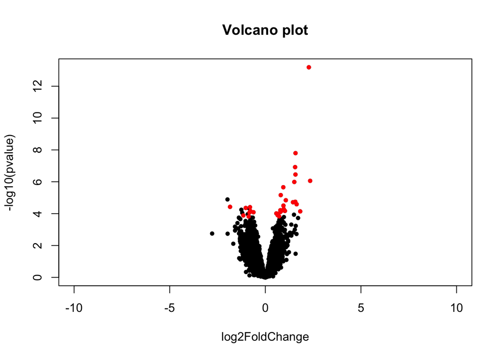

```r
with(res_R848, plot(log2FoldChange, -log10(pvalue), pch=20, main="Volcano plot", xlim=c(-10,10)))
with(subset(res_R848, padj<.05 ), points(log2FoldChange, -log10(pvalue), pch=20, col="red"))
```

### MA plot R848 vs unstim

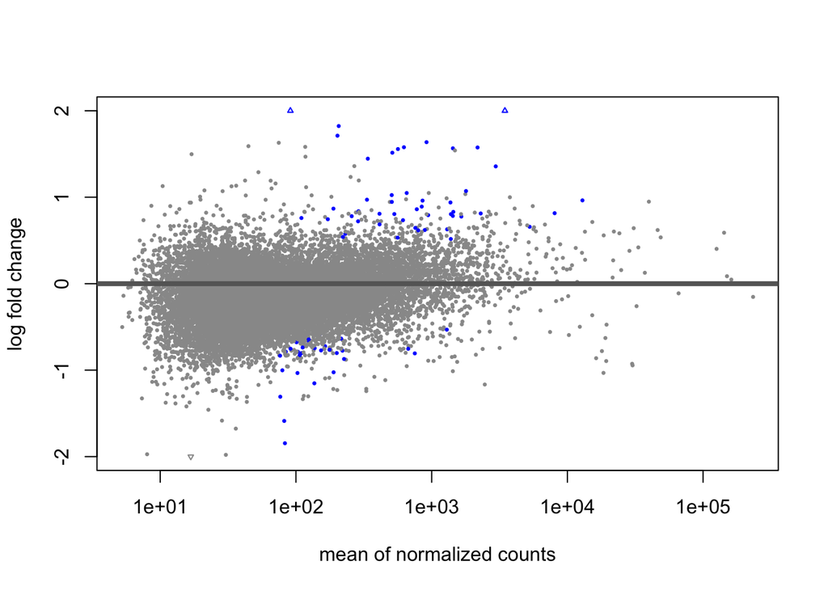

```r
plotMA(res_R848, ylim=c(-2,2))
```

### TOP differentially expressed genes R848 vs unstim

```r
setDT(resOrdered_R848, keep.rownames = "ensembl")
resOrdered_R848 <- left_join(resOrdered_R848, gencode_30, by = "ensembl")
resOrdered_R848_top = resOrdered_R848[order(resOrdered_R848$padj) ,]
resOrdered_R848_top = head(resOrdered_R848)
data.table(resOrdered_R848_top)
```

| ensembl | baseMean | log2FoldChange | lfcSE | stat | pvalue | padj | symbol |
| --- | --- | --- | --- | --- | --- | --- | --- |
| ENSG00000232810.4 | 3464.4317 | 2.275567 | 0.3034762 | 7.498338 | 6.463226e-14 | 5.851158e-10 | TNF |
| ENSG00000133316.15 | 624.7156 | 1.577952 | 0.2791834 | 5.652028 | 1.585654e-08 | 7.177464e-05 | WDR74 |
| ENSG00000106366.8 | 564.2208 | 1.556959 | 0.2940847 | 5.294253 | 1.195038e-07 | 3.606228e-04 | SERPINE1 |
| ENSG00000144802.11 | 2178.3868 | 1.575259 | 0.3091927 | 5.094750 | 3.492021e-07 | 7.903317e-04 | NFKBIZ |
| ENSG00000113302.4 | 91.0165 | 2.343457 | 0.4764084 | 4.919008 | 8.698406e-07 | 1.542906e-03 | IL12B |
| ENSG00000111678.11 | 512.9628 | 1.514756 | 0.3099408 | 4.887242 | 1.022582e-06 | 1.542906e-03 | C12orf57 |

# DESeq2: DEX vs unstim

### Number of differentially expressed genes

```r
# generate results table for DEX vs unstim
res_DEX <- results(dds, name="Stimulation_DEX_vs_unstim")
sum(res_DEX$padj < 0.05, na.rm=TRUE)
```

[1] 512

```r
resOrdered_DEX <- res_DEX[order(res_DEX$pvalue),]
resOrdered_DEX <- as.data.frame(resOrdered_DEX)
```

### Vulcano plot DEX vs unstim

```r
head(res_DEX)
```

log2 fold change (MLE): Stimulation DEX vs unstim Wald test p-value: Stimulation DEX vs unstim DataFrame with 6 rows and 6 columns baseMean log2FoldChange lfcSE stat pvalue ENSG00000000003.14 19.7415 0.0387835 0.558915 0.0693906 0.944678739 ENSG00000000419.12 220.9662 -0.6075668 0.277813 -2.1869666 0.028744961 ENSG00000000457.14 90.9514 0.0725621 0.282966 0.2564339 0.797615852 ENSG00000000460.17 28.2773 -0.1466819 0.317582 -0.4618707 0.644174046 ENSG00000000938.13 516.4009 0.8431192 0.227244 3.7101914 0.000207103 ENSG00000000971.15 50.2049 -1.3107216 0.540463 -2.4251824 0.015300695 padj ENSG00000000003.14 0.9817858 ENSG00000000419.12 0.2226123 ENSG00000000457.14 0.9291432 ENSG00000000460.17 0.8526005 ENSG00000000938.13 0.0176427 ENSG00000000971.15 0.1682102

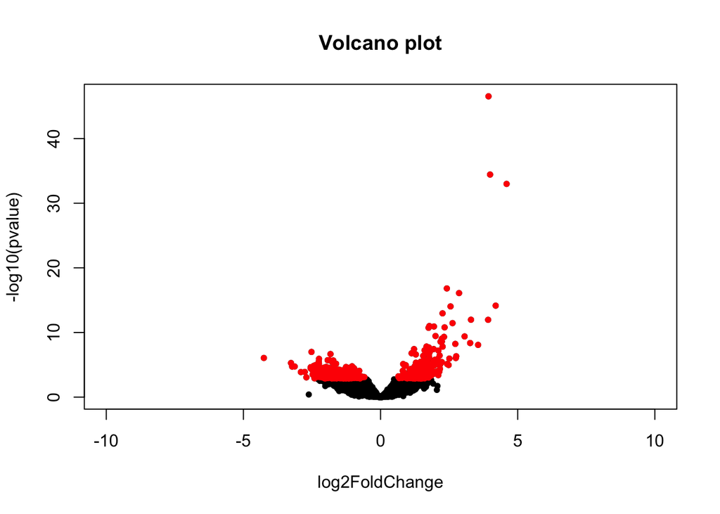

```r
with(res_DEX, plot(log2FoldChange, -log10(pvalue), pch=20, main="Volcano plot", xlim=c(-10,10)))
with(subset(res_DEX, padj<.05 ), points(log2FoldChange, -log10(pvalue), pch=20, col="red"))
```

### MA plot DEX vs unstim

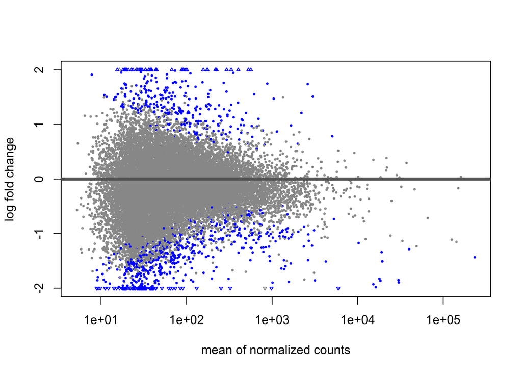

```r
plotMA(res_DEX, ylim=c(-2,2))
```

### TOP differentially expressed genes DEX vs unstim

```r
setDT(resOrdered_DEX, keep.rownames = "ensembl")
resOrdered_DEX <- left_join(resOrdered_DEX, gencode_30, by = "ensembl")
resOrdered_DEX_top = resOrdered_DEX[order(resOrdered_DEX$padj) ,]
resOrdered_DEX_top = head(resOrdered_DEX)
data.table(resOrdered_DEX_top)
```

| ensembl | baseMean | log2FoldChange | lfcSE | stat | pvalue | padj | symbol |
| --- | --- | --- | --- | --- | --- | --- | --- |
| ENSG00000096060.14 | 529.13673 | 3.935056 | 0.2725053 | 14.440291 | 2.886231e-47 | 5.482972e-43 | FKBP5 |
| ENSG00000157514.16 | 401.94359 | 3.992863 | 0.3227169 | 12.372650 | 3.674949e-35 | 3.490650e-31 | TSC22D3 |
| ENSG00000109906.13 | 87.73163 | 4.594632 | 0.3796370 | 12.102699 | 1.021955e-33 | 6.471358e-30 | ZBTB16 |
| ENSG00000100100.12 | 175.17442 | 2.416251 | 0.2834354 | 8.524876 | 1.529735e-17 | 7.265092e-14 | PIK3IP1 |
| ENSG00000104611.12 | 43.65373 | 2.861496 | 0.3434616 | 8.331342 | 7.993103e-17 | 3.036900e-13 | SH2D4A |
| ENSG00000179593.16 | 37.56297 | 4.196973 | 0.5392463 | 7.783035 | 7.080493e-15 | 2.241802e-11 | ALOX15B |

# DESeq2: Il4 vs unstim

### Number of differentially expressed genes

```r
res_IL4 <- results(dds, name="Stimulation_IL4_vs_unstim")
sum(res_IL4$padj < 0.05, na.rm=TRUE)
```

[1] 36

```r
resOrdered_IL4 <- res_IL4[order(res_IL4$pvalue),]
resOrdered_IL4 <- as.data.frame(resOrdered_IL4)
```

### Vulcano plot IL4 vs unstim

```r
head(res_IL4)
```

log2 fold change (MLE): Stimulation IL4 vs unstim Wald test p-value: Stimulation IL4 vs unstim DataFrame with 6 rows and 6 columns baseMean log2FoldChange lfcSE stat pvalue ENSG00000000003.14 19.7415 0.4263331 0.589869 0.722759 0.469828 ENSG00000000419.12 220.9662 0.2950414 0.291466 1.012267 0.311410 ENSG00000000457.14 90.9514 0.0428686 0.302538 0.141697 0.887320 ENSG00000000460.17 28.2773 0.1772684 0.334985 0.529183 0.596678 ENSG00000000938.13 516.4009 -0.2018429 0.242924 -0.830891 0.406035 ENSG00000000971.15 50.2049 -0.2419492 0.571295 -0.423510 0.671923 padj ENSG00000000003.14 0.895937 ENSG00000000419.12 0.823592 ENSG00000000457.14 0.983006 ENSG00000000460.17 0.932477 ENSG00000000938.13 0.868264 ENSG00000000971.15 0.946939

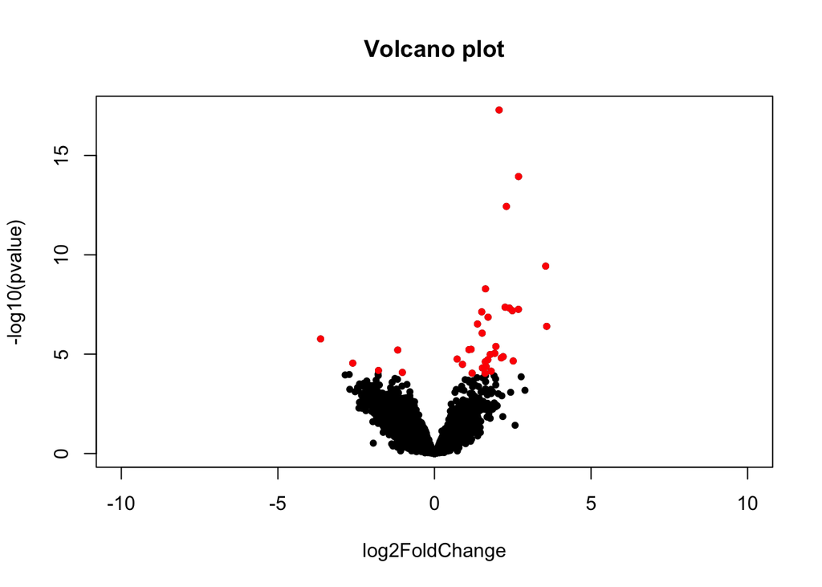

```r
with(res_IL4, plot(log2FoldChange, -log10(pvalue), pch=20, main="Volcano plot", xlim=c(-10,10)))
with(subset(res_IL4, padj<.05 ), points(log2FoldChange, -log10(pvalue), pch=20, col="red"))
```

### MA plot IL4 vs unstim

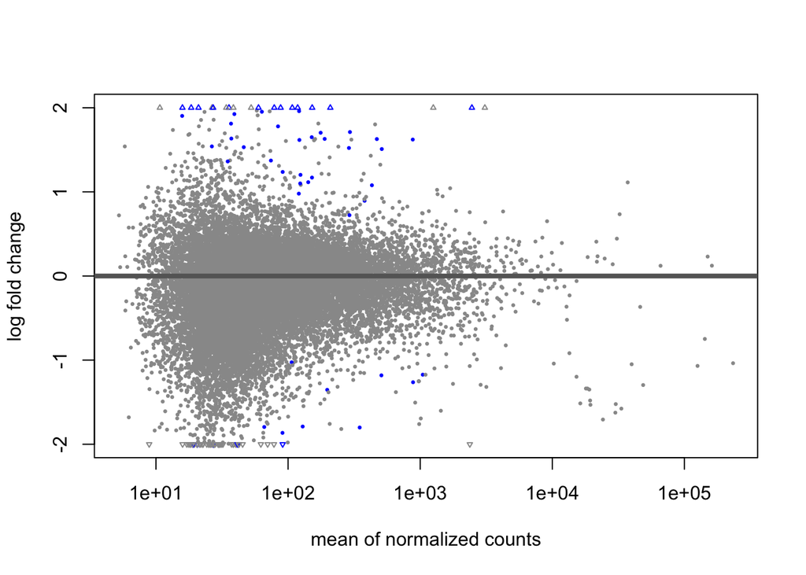

```r
plotMA(res_IL4, ylim=c(-2,2))
```

### TOP differentially expressed genes IL4 vs unstim

```r
setDT(resOrdered_IL4, keep.rownames = "ensembl")
resOrdered_IL4 <- left_join(resOrdered_IL4, gencode_30, by = "ensembl")
resOrdered_IL4_top = resOrdered_IL4[order(resOrdered_IL4$padj) ,]
resOrdered_IL4_top = head(resOrdered_IL4)
data.table(resOrdered_IL4_top)
```

| ensembl | baseMean | log2FoldChange | lfcSE | stat | pvalue | padj | symbol |
| --- | --- | --- | --- | --- | --- | --- | --- |
| ENSG00000167642.13 | 208.69393 | 2.064232 | 0.2386389 | 8.650025 | 5.148833e-18 | 9.781238e-14 | SPINT2 |
| ENSG00000189221.9 | 87.82457 | 2.683514 | 0.3475068 | 7.722191 | 1.143466e-14 | 1.086121e-10 | MAOA |
| ENSG00000114737.15 | 107.58733 | 2.296165 | 0.3159594 | 7.267278 | 3.668044e-13 | 2.322728e-09 | CISH |
| ENSG00000168899.5 | 118.20521 | 3.551349 | 0.5667661 | 6.265986 | 3.704726e-10 | 1.759467e-06 | VAMP5 |
| ENSG00000109861.16 | 469.85660 | 1.627873 | 0.2786266 | 5.842491 | 5.142588e-09 | 1.953875e-05 | CTSC |
| ENSG00000248187.1 | 27.08185 | 2.254981 | 0.4117542 | 5.476521 | 4.337683e-08 | 1.304200e-04 | AC078850.1 |

# DESeq2: ATP vs unstim

### Number of differentially expressed genes

```r
# generate results table for ATP vs unstim
res_ATP <- results(dds, name="Stimulation_ATP_vs_unstim")
sum(res_ATP$padj < 0.05, na.rm=TRUE)
```

[1] 634

```r
resOrdered_ATP <- res_ATP[order(res_ATP$pvalue),]
resOrdered_ATP <- as.data.frame(resOrdered_ATP)
```

### Vulcano plot ATP vs unstim

```r
head(res_ATP)
```

log2 fold change (MLE): Stimulation ATP vs unstim Wald test p-value: Stimulation ATP vs unstim DataFrame with 6 rows and 6 columns baseMean log2FoldChange lfcSE stat pvalue ENSG00000000003.14 19.7415 -0.5188666 0.839380 -0.618154 0.5364736 ENSG00000000419.12 220.9662 0.0888658 0.404946 0.219451 0.8262989 ENSG00000000457.14 90.9514 0.3390229 0.409185 0.828533 0.4073687 ENSG00000000460.17 28.2773 0.6670709 0.445294 1.498047 0.1341210 ENSG00000000938.13 516.4009 0.0640862 0.333560 0.192128 0.8476420 ENSG00000000971.15 50.2049 -1.9871958 0.837970 -2.371440 0.0177189 padj ENSG00000000003.14 0.790980 ENSG00000000419.12 0.937291 ENSG00000000457.14 0.703846 ENSG00000000460.17 0.424350 ENSG00000000938.13 0.944771 ENSG00000000971.15 0.153264

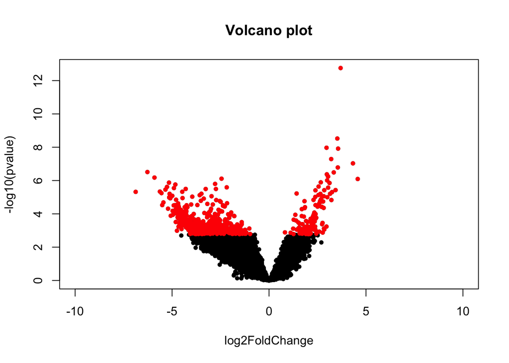

```r
with(res_ATP, plot(log2FoldChange, -log10(pvalue), pch=20, main="Volcano plot", xlim=c(-10,10)))
with(subset(res_ATP, padj<.05 ), points(log2FoldChange, -log10(pvalue), pch=20, col="red"))
```

### MA plot ATP vs unstim

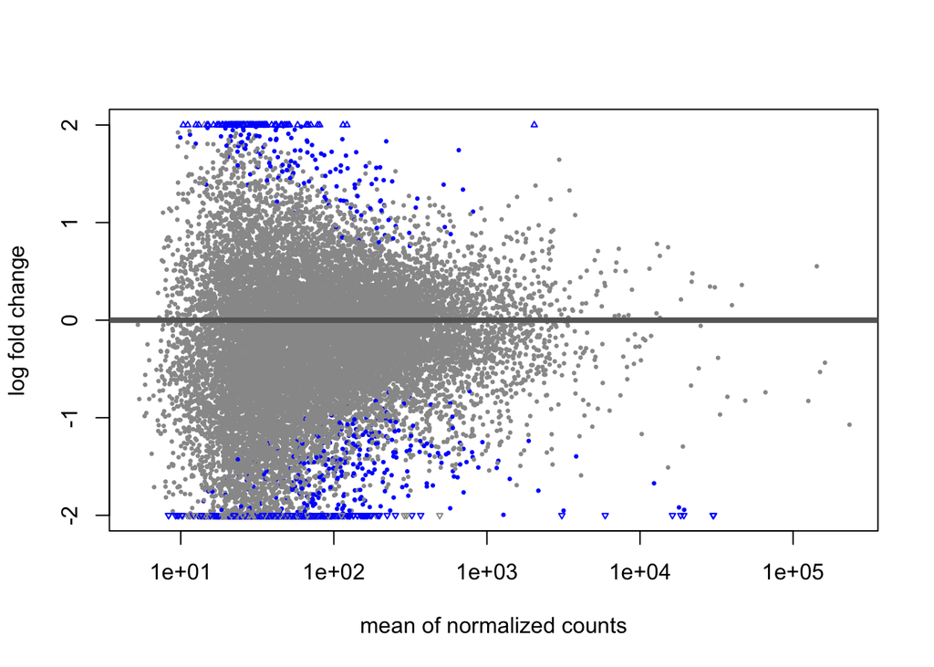

```r
plotMA(res_ATP, ylim=c(-2,2))
```

### TOP differentially expressed genes ATP vs unstim

```r
setDT(resOrdered_ATP, keep.rownames = "ensembl")
resOrdered_ATP <- left_join(resOrdered_ATP, gencode_30, by = "ensembl")
resOrdered_ATP_top = resOrdered_ATP[order(resOrdered_ATP$padj) ,]
resOrdered_ATP_top = head(resOrdered_ATP)
data.table(resOrdered_ATP_top)
```

| ensembl | baseMean | log2FoldChange | lfcSE | stat | pvalue | padj | symbol |
| --- | --- | --- | --- | --- | --- | --- | --- |
| ENSG00000176160.10 | 28.88030 | 3.691756 | 0.5011471 | 7.366612 | 1.750187e-13 | 3.324830e-09 | HSF5 |
| ENSG00000268324.2 | 34.95809 | 3.521293 | 0.5936552 | 5.931545 | 3.000969e-09 | 2.850471e-05 | LRRC2-AS1 |
| ENSG00000227236.2 | 25.23161 | 2.964926 | 0.5184363 | 5.718979 | 1.071658e-08 | 5.745395e-05 | AL583844.1 |
| ENSG00000271013.1 | 30.81041 | 3.561096 | 0.6249349 | 5.698347 | 1.209748e-08 | 5.745395e-05 | LRRC37A9P |
| ENSG00000261126.7 | 29.14945 | 3.205792 | 0.5885195 | 5.447214 | 5.116476e-08 | 1.943954e-04 | RBFADN |
| ENSG00000254122.2 | 33.17661 | 4.327384 | 0.8103602 | 5.340074 | 9.290839e-08 | 2.941635e-04 | PCDHGB7 |